# Machine Learning Base introduce

```
来自 1998 年 Tom Mitchell 的定义， "对于某类任务T和性能度量P，如果一个计算机程序在T上以P衡量的性能随着经验E而自我完善，那么我们称这个计算机程序在从经验E学习。"
```

[figure not shown]

# Perceptron (感知机)

**任务** : 求一条线$wx+b=0$ 对不同类别的点进行二分类

**类型** : 监督学习

**模型** : 感知机 $f(x)=sign(wx+b)$, 其中$w$叫做权重(weight)， $b$叫做偏置(bias)

**评价方法** : $\min \{ \sum {{\rm{(y(wx + b) < 0)}}} \}$

**优化方法** : PLA/Pocket

# PLA (Percetron Learning Algorithm)

- **Input**: traing data ($T = \{(x_{0}, y_{0}), (x_{1}, y_{1}), ..., (x_{i}, y_{i})\}$)
- **Output**: $(w, b)$
  - init $(w, b)\rightarrow(0,0)$ , $i\rightarrow 0$
  - while $i != len(T)$ do
    - if $y_{i}(wx_{i}+b) <= 0$ then
      - $(w, b) \rightarrow (w, b) + y_{i}x_{i}$
      - $i\rightarrow 0$
    - else
      - $i=i+1$
    - end if
  - end while

[figure not shown]

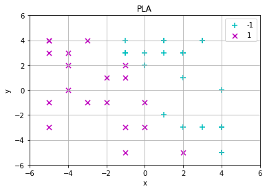

```python
import numpy as np
import matplotlib
import matplotlib.pyplot as plt

LEN = 40
x = np.random.randint(-5,5, (LEN,2))
line = np.random.randint(-5,5, (2, 1))
#  2y - 3x
label = np.sign(np.dot(x, line))
label[label == 0] = 1
fig = plt.figure(1)
idx_0 = np.where(label[:, 0] == -1)
p0 = plt.scatter(x[idx_0,1], x[idx_0,0], marker = '+', color = 'c', label='-1', s = 50)
idx_1 = np.where(label[:, 0] == 1)
p1 = plt.scatter(x[idx_1,1], x[idx_1,0], marker = 'x', color = 'm', label='1', s = 50)
plt.title('PLA')
plt.xlabel('x')
plt.ylabel('y')
plt.xlim((-6,6))
plt.ylim((-6,6))
plt.legend()
plt.grid(True)
plt.show()
```

```python
cnt = 0
pla = np.zeros((2,1))
_update = 0

while cnt<LEN:
    _update = np.sign(np.dot(x[cnt,:], pla)) * label[cnt, 0]
    if _update <= 0:
        _x = x[cnt, :]
        _x.shape = (1,2)
        _x = np.transpose(_x)
        pla = pla + _x*label[cnt, 0]
        cnt = 0
    else:
        cnt = cnt+1
        continue
print(pla)
```

```
[[-3.]
 [-7.]]
```

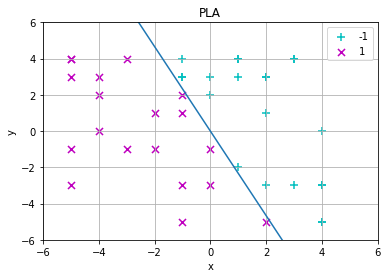

```python
fig = plt.figure(1)
idx_0 = np.where(label[:, 0] == -1)
p0 = plt.scatter(x[idx_0,1], x[idx_0,0], marker = '+', color = 'c', label='-1', s = 50)
idx_1 = np.where(label[:, 0] == 1)
p1 = plt.scatter(x[idx_1,1], x[idx_1,0], marker = 'x', color = 'm', label='1', s = 50)
plt.title('PLA')
plt.xlabel('x')
plt.ylabel('y')
plt.xlim((-6,6))
plt.ylim((-6,6))
plt.legend()
plt.grid(True)

k = -pla[1,:] / pla[0,:]
line_x = np.linspace(-5,5,50)
line_y = k*line_x
plt.plot(line_x,line_y)
plt.show()
```

# POCKET Algorithm

- **Input**: traing data ($T = \{(x_{0}, y_{0}), (x_{1}, y_{1}), ..., (x_{i}, y_{i})\}$)
- **Output**: $(w, b)$
  - init $(w_{best}, b_{best}) \rightarrow random$
  - $loss_{min} \leftarrow sum(sign(w_{best}x + b_{best}) != y)$
  - for $i= 0\rightarrow1000$ do
    - init $(w, b)\rightarrow random$ and $j\rightarrow 0$
    - Save error label data to $T_{error} = \{(x_{0}, y_{0}), (x_{1}, y_{1}), ..., (x_{err}, y_{err})\}$
    - while $j != len(T_{error})$ do
      - $(\bar{w}, \bar{b}) \rightarrow (w, b) + y_{j}x_{j}$
      - $loss \leftarrow sum(sign(\bar{w}x + \bar{b}) != y)$
      - if $loss < loss_{min}$ then
        - break
      - end if
      - $j=j+1$
    - end while
    - if $j != len(y_{err})$
      - $(w_{best}, b_{best}) \leftarrow (\bar{w}, \bar{b})$
      - $loss_{min} \leftarrow loss$
    - end if
    - j = 0
  - end for

```python
def cal_loss(_pocket, _x, _label):
    _cal = np.sign(np.dot(_x, _pocket))
    _cal.shape = (40,1)
    idx = np.where(_cal[:, 0] != _label[:, 0])
    loss = np.sum(_cal[:, 0] != _label[:, 0])
    return list(idx[0]), loss

# random init best pocket and min loss value
pocket_best = np.random.randint(-5,5, (2,1))
_, min_loss = cal_loss(pocket_best, x, label)


for i in range(15):
    # random pocket and cur loss for each period
    pocket = np.random.randint(-5,5, (2,1))
    _pocket = pocket
    idx, cur_loss = cal_loss(pocket, x, label)
    while cnt < len(idx):
        _x = x[idx[cnt], :]
        _x.shape = (2,1)
        _pocket = pocket + _x * label[idx[cnt], 0]
        _, cur_loss = cal_loss(_pocket, x, label)
        # compare cur loss with min loss
        if cur_loss < min_loss:
            break
        else:
            cnt = cnt + 1
    if cnt != len(idx):
        pocket_best = _pocket
        _, min_loss = cal_loss(pocket_best, x, label)
    cnt = 0

pocket = pocket_best
print(pocket)
```

```
[[-2]
 [-4]]
```

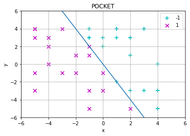

```python
fig = plt.figure(1)
idx_0 = np.where(label[:, 0] == -1)
p0 = plt.scatter(x[idx_0,1], x[idx_0,0], marker = '+', color = 'c', label='-1', s = 50)
idx_1 = np.where(label[:, 0] == 1)
p1 = plt.scatter(x[idx_1,1], x[idx_1,0], marker = 'x', color = 'm', label='1', s = 50)
plt.title('POCKET')
plt.xlabel('x')
plt.ylabel('y')
plt.xlim((-6,6))
plt.ylim((-6,6))
plt.legend()
plt.grid(True)

k = -pocket[1,:] / pocket[0,:]
line_x = np.linspace(-5,5,50)
line_y = k*line_x
plt.plot(line_x,line_y)
plt.show()
```

[figure not shown]

# SVM (Support Vector Machine)

**任务** : 对线性/非线性可分不同类别的点进行二分类

**类型** : 监督学习

**模型** : $f(x)=sign(wx+b)$

**评价方法** : $\mathop {\min }\limits_{w,b} (\frac{1}{2}||w|{|^2}) + C\sum\limits_{i = 1}^m {\max (0,1 - {y_i}({w^T}{x_i}{\rm{ + }}b))}$

> *s.t.* ${y_i}(w{x_{_i}} + b) - 1 \ge 0,i = 1,2,...,N$

**优化方法** : 核技巧/SMO

```python
import numpy as np
import matplotlib.pyplot as plt
import matplotlib.patches as mpatches
from matplotlib import style
style.use("ggplot")
from sklearn import svm
from sklearn.datasets.samples_generator import make_blobs

## 测试数据生成
_x = np.random.randint(-10, 10, (400, 2))
_ = np.linalg.norm(_x, axis=1)
circle_in = _x[_<5]
circle_out = _x[_>8]
x = np.vstack((circle_in, circle_out))
y = np.zeros(x.shape[0])
y[0:circle_in.shape[0]] = 1

## 运行SVC核
svc_rbf = svm.SVC(kernel='rbf', C=1e3, gamma=0.1)
svc_poly = svm.SVC(kernel='poly', C=1e3, degree=2)
print(svc_rbf)
print(svc_poly)
```

```
SVC(C=1000.0, cache_size=200, class_weight=None, coef0=0.0,
  decision_function_shape='ovr', degree=3, gamma=0.1, kernel='rbf',
  max_iter=-1, probability=False, random_state=None, shrinking=True,
  tol=0.001, verbose=False)
SVC(C=1000.0, cache_size=200, class_weight=None, coef0=0.0,
  decision_function_shape='ovr', degree=2, gamma='auto', kernel='poly',
  max_iter=-1, probability=False, random_state=None, shrinking=True,
  tol=0.001, verbose=False)
```

[figure not shown]

# LR (Logisitic Regeression)

**任务** : 对线性/非线性可分不同类别的点进行多分类

**类型** : 监督学习

**模型** : 3层fc nn, output layer(softmax) : ${y_i} = \frac{{{e^{w{x_n} + b}}}}{{\sum\limits_{i = 1}^C {{e^{w{x_i} + b}}} }}$

**评价方法** : $- \sum\limits_{i = 1}^N {{y_i}\log \frac{{{e^{w{x_i} + b}}}}{{\sum\limits_{j = 1}^C {{e^{w{x_j} + b}}} }}}$

**优化方法** : Gradient Descent/SGD/ADAM/Adagrad/RMSprop

[figure not shown]

```python
import numpy as np
import tensorflow as tf
import matplotlib.pyplot as plt
from sklearn.datasets.samples_generator import make_blobs
import time
import os
os.environ['TF_CPP_MIN_LOG_LEVEL']='2'

DIMENSION = 2
KNUM = 4
SAMPLE_CNT = 240

def init_variable(name, shape):
    return(tf.get_variable(name, shape=shape, initializer=tf.contrib.layers.xavier_initializer()))

# 测试数据生成
x_data, y_data = make_blobs(n_samples=SAMPLE_CNT, n_features=DIMENSION, centers=KNUM, center_box=(-20, 20), cluster_std=1.5)
x = x_data.tolist()
label=np.zeros((SAMPLE_CNT, KNUM))

label[y_data==0] = [0,0,0,1]
label[y_data==1] = [0,0,1,0]
label[y_data==2] = [0,1,0,0]
label[y_data==3] = [1,0,0,0]

y = label.tolist()
keep_prob = tf.placeholder(tf.float32)
prediction_value = y.copy()

# 生成学习网络
# layer0: input
xs = tf.placeholder("float", [None, 2])
ys = tf.placeholder("float", [None, 4])
keep_prob = tf.placeholder(tf.float32)

# layer1:
W1 = init_variable('W1', [2,20])
bias1 = init_variable('b1', [1,20])
o1 = tf.nn.relu(tf.matmul(xs, W1) + bias1)
o1_drop = tf.nn.dropout(o1, keep_prob)

# layer2:
W2 = init_variable('W2', [20,20])
bias2 = init_variable('b2', [1,20])
o2 = tf.nn.relu(tf.matmul(o1_drop, W2) + bias2)
o2_drop = tf.nn.dropout(o2, keep_prob)

# layer3: output
W3 = init_variable('W3', [20,4])
bias3 = init_variable('b3', [1,4])
#predict = tf.nn.softmax(tf.matmul(o2_drop, W3) + bias3)
o3 = tf.matmul(o2_drop, W3) + bias3
predict = tf.nn.softmax(o3)

# loss  sum( y*log(predict) )
loss = tf.reduce_mean(tf.nn.softmax_cross_entropy_with_logits(logits=o3, labels=ys))
#loss = tf.reduce_mean(-tf.reduce_sum(ys*tf.log(predict), reduction_indices=[1]))

# train method
#train = tf.train.GradientDescentOptimizer(0.1).minimize(loss)
train = tf.train.AdamOptimizer(1e-3).minimize(loss)

#init all variables, it will be activated by use sess.run(init)
init = tf.global_variables_initializer()

with tf.Session() as sess:
    sess.run(init)
    for i in range(200):
        sess.run(train, feed_dict={xs:x, ys:y, keep_prob: 0.5})
        if i % 10 == 0:
            prediction_value = sess.run(predict, feed_dict={xs:x, keep_prob: 1})
            print(sess.run(loss, feed_dict={xs:x, ys:y, keep_prob: 1}))
```

```
WARNING:tensorflow:From <ipython-input-1-f07e6545bb47>:56: softmax_cross_entropy_with_logits (from tensorflow.python.ops.nn_ops) is deprecated and will be removed in a future version.
Instructions for updating:

Future major versions of TensorFlow will allow gradients to flow
into the labels input on backprop by default.

See tf.nn.softmax_cross_entropy_with_logits_v2.

9.013017
6.49734
4.688036
3.5733612
2.7522929
2.1041882
1.5808904
1.2115903
0.93266517
0.73520064
0.61183685
0.5383428
0.49589163
0.47452718
0.4646661
0.46033302
0.45716488
0.45751208
0.45871666
0.46209347
```

[figure not shown]

# LR (Linear Regeression)

**任务** : 对一组数据进行曲线拟合

**类型** : 监督学习

**模型** : 2层fc nn, output layer : ${y_i} = w{x_i} + b$

**评价方法** : $\sum\limits_{i = 1}^N {{{\left( {{{\rm{y}}_i} - (w{x_i} + b)} \right)}^2}}$

**优化方法** : Gradient Descent/SGD/ADAM/Adagrad/RMSprop

```python
import numpy as np
import tensorflow as tf
import matplotlib.pyplot as plt
import time
import os
os.environ['TF_CPP_MIN_LOG_LEVEL']='2'

# 测试数据生成
x_data = np.linspace(-1, 1, 300)[:, np.newaxis]
noise = np.random.normal(0, 0.05, x_data.shape)
y_data = np.square(x_data) - 0.5 + noise

# 生成学习网络
# layer0: input
xs = tf.placeholder(tf.float32, [None, 1])
ys = tf.placeholder(tf.float32, [None, 1])

# layer1:
W1 = tf.Variable(tf.random_normal([1,10]))
bias1 = tf.Variable(tf.zeros([1, 10]) + 0.1)
o1 = tf.nn.relu(tf.matmul(xs, W1) + bias1)

# layer2: output
W2 = tf.Variable(tf.random_normal([10,1]))
bias2 = tf.Variable(0.1)
predict = tf.matmul(o1, W2) + bias2

# loss
loss = tf.reduce_mean(tf.reduce_sum(tf.square(ys - predict),
                     reduction_indices=[1]))

# train method
train = tf.train.GradientDescentOptimizer(0.1).minimize(loss)

#init all variables, it will be activated by use sess.run(init)
init = tf.global_variables_initializer()


with tf.Session() as sess:
    sess.run(init)
    for i in range(1000):
        sess.run(train, feed_dict={xs:x_data, ys:y_data})
        if i % 100 == 0:
            prediction_value = sess.run(predict, feed_dict={xs:x_data})
            print(sess.run(loss, feed_dict={xs:x_data, ys:y_data}))
```

```
0.21007633
0.009326225
0.0065052332
0.0041997177
0.0037967209
0.003648324
0.0035490533
0.0034687535
0.003410836
0.0033446297
```

[figure not shown]

# KMEANS

**任务** : 对未标记的点进行多分类

**类型** : 非监督学习

**模型** : ${y_j} - > \min \sum\limits_{i = 1}^K {{{({x_j} - {k_i})}^2}}$

**评价方法** : $\sum\limits_{i = 1}^K {\sum\limits_{j = 1}^N {{{({x_j} - {k_i})}^2}} }$

**优化方法** : ${k_j} - > \frac{1}{N}\sum\limits_{i = 1}^N {{x_i} \bullet ({y_i} = = j)}$

# KMEANS Algorithm

```python
import numpy as np
import matplotlib
import matplotlib.pyplot as plt
from sklearn.datasets.samples_generator import make_blobs

DIMENSION = 2
KNUM = 4
SAMPLE_CNT = 240
train_step = 100


def label_reset(x, kpoint):
    _label = np.zeros((x.shape[0], 1))
    for i in range(0, x.shape[0]):
        _ = np.linalg.norm(x[i,:] - kpoint, axis=1)
        _label[i] = np.argmin(_, 0)

    return _label


def kpoint_reset(x, label):
    _kpoint = np.zeros((KNUM, DIMENSION))
    idx = 0
    for i in range(0, KNUM):
        idx = np.where(label[:, 0] == i)
        _kpoint[i] = np.mean(x[idx], axis=0)
    return _kpoint

def cal_total(x, kpoint, label):
    _sum = 0
    for i in range(0, KNUM):
        idx = np.where(label[:, 0] == i)
        _linalg = np.linalg.norm(x[idx] - kpoint[i], axis=1)
        _sum += np.sum(_linalg)
    _sum /= SAMPLE_CNT
    return _sum

'''
# x, y, label
x = np.zeros((SAMPLE_CNT, DIMENSION))
x = np.random.randint(-20, 20, (SAMPLE_CNT, DIMENSION))
'''
x, _ = make_blobs(n_samples=SAMPLE_CNT, n_features=DIMENSION, centers=KNUM, center_box=(-20, 20), cluster_std=1.5)

label = np.zeros((SAMPLE_CNT, 1))

#kmeans init
kpoint = np.random.randint(-20, 20, (KNUM, DIMENSION))
kpoint_min = kpoint.copy()

label = label_reset(x, kpoint)
label_min = label.copy()

sum = cal_total(x, kpoint, label)
sum_min = sum
delta = sum

for i in range(train_step):
    kpoint = np.random.randint(-20, 20, (KNUM, DIMENSION))
    label = label_reset(x, kpoint)
    sum = cal_total(x, kpoint, label)
    delta = sum
    while delta > 0.001:
        kpoint = kpoint_reset(x, label)
        label = label_reset(x, kpoint)
        _sum = cal_total(x, kpoint, label)
        delta = sum - _sum
        sum = _sum
        #print("sum: %f" %sum)
    if sum < sum_min:
        print("Update sum_min: %f" %sum)
        sum_min = sum
        kpoint_min = kpoint.copy()
        label_min = label.copy()
print(sum)
```

[output not shown]

```
Update sum_min: 1.577934
Update sum_min: 1.577856
1.5780844366637838
```

[figure not shown]

# CNN

**任务** : OCR end-to-end 识别

**类型** : 监督学习

**模型** : 3层cnn + 3层relu + 2层fc, output layer(softmax) : ${y_i} = \frac{{{e^{w{x_n} + b}}}}{{\sum\limits_{i = 1}^C {{e^{w{x_i} + b}}} }}$

**评价方法** : $- \sum\limits_{i = 1}^N {{y_i}\log \frac{{{e^{w{x_i} + b}}}}{{\sum\limits_{j = 1}^C {{e^{w{x_j} + b}}} }}}$

**优化方法** : Gradient Descent/SGD/ADAM/Adagrad/RMSprop

[figure not shown]

# Convolution

翻转->移动->乘积->求和

$f[x,y]*g[x,y] = \sum\limits_{{n_1} = - \infty }^\infty {\sum\limits_{{n_2} = - \infty }^\infty {f[{n_1},{n_2}]\bullet g[x - {n_1},y - {n_2}]} }$

[figure not shown]

```
[[255. 255. 255.]
 [  1.   1.   1.]
 [  1.   1.   1.]]
-762.0
```

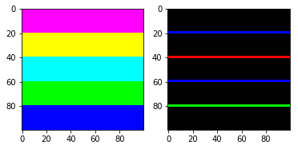

```python
import cv2
import matplotlib.pyplot as plt
import numpy as np
import sys
%matplotlib inline

img = np.ones((100,100,3))
img[0:20,:,1] = 255
img[20:40,:,2] = 255
img[40:100,:,0] = 255
img[60:80,:,2] = 255
img[80:100,:,1] = 255

prewitt = np.array([[-1,-1,-1],
          [0,0,0],
          [1,1,1]])
res = cv2.filter2D(img,-1,prewitt)
regular = np.uint8(res)
print(img[19:22,19:22,1])
print(res[20,20,1])

plt.figure()
plt.subplot(1,2,1)
plt.imshow(img)
plt.subplot(1,2,2)
plt.imshow(regular)
plt.show()
```

# LeNet、AlexNet、GoogLeNet、VGG、ResNet

[figure not shown]

# Mask R-CNN Segment

[figure not shown]

# Mask R-CNN Post

[figure not shown]

# DeepDream

[figure not shown]

# Style-transfer

[figure not shown]

# Gramian 矩陣

設 $A$ 為一個 $m\times n$ 階實矩陣，$n$ 階方陣 $G=[g_{ij}]=A^TA$ 稱為 Gramian 或 Gram 矩陣，也有人稱之為交互乘積 (cross-product) 矩陣。考慮 $A$ 的行向量表達式 $A=\begin{bmatrix} \mathbf{a}_1&\mathbf{a}_2&\cdots&\mathbf{a}_n \end{bmatrix}$，$\mathbf{a}_i\in\mathbb{R}^m$，則: $$G=A^TA=\begin{bmatrix} \mathbf{a}_1^T\\ \mathbf{a}_2^T\\ \vdots\\ \mathbf{a}_n^T \end{bmatrix}\begin{bmatrix} \mathbf{a}_1&\mathbf{a}_2&\cdots&\mathbf{a}_n \end{bmatrix}=\begin{bmatrix} \mathbf{a}_1^T\mathbf{a}_1&\mathbf{a}_1^T\mathbf{a}_2&\cdots&\mathbf{a}_1^T\mathbf{a}_n\\ \mathbf{a}_2^T\mathbf{a}_1&\mathbf{a}_2^T\mathbf{a}_2&\cdots&\mathbf{a}_2^T\mathbf{a}_n\\ ~&~&~&~\\ \mathbf{a}_n^T\mathbf{a}_1&\mathbf{a}_n^T\mathbf{a}_2&\cdots&\mathbf{a}_n^T\mathbf{a}_n \end{bmatrix}$$

```python
import numpy as np

A = np.random.randint(0,5, (2,2))

B = np.dot(A.T, A)
print(A)
print(B)
```

```
[[1 1]
 [3 4]]
[[10 13]
 [13 17]]
```

```python
        parser.add_argument('--content_layers', nargs='+', type=str, default=['conv4_2'], help='VGG19 layers used for content loss')
        parser.add_argument('--style_layers', nargs='+', type=str, default=['relu1_1', 'relu2_1', 'relu3_1', 'relu4_1', 'relu5_1'],
                        help='VGG19 layers used for style loss')

        """https://github.com/hwalsuklee/tensorflow-style-transfer/blob/master/style_transfer.py"""
        """ compute loss """
        L_content = 0
        L_style = 0
        for id in self.Fs:
            if id in self.CONTENT_LAYERS:
                ## content loss ##

                F = self.Fs[id]            # content feature of x
                P = self.Ps[id]            # content feature of p

                _, h, w, d = F.get_shape() # first return value is batch size (must be one)
                N = h.value*w.value        # product of width and height
                M = d.value                # number of filters

                w = self.CONTENT_LAYERS[id]# weight for this layer

                # You may choose different normalization constant
                if self.content_loss_norm_type==1:
                    L_content += w * tf.reduce_sum(tf.pow((F-P), 2)) / 2 # original paper
                elif self.content_loss_norm_type == 2:
                    L_content += w * tf.reduce_sum(tf.pow((F-P), 2)) / (N*M) #artistic style transfer for videos
                elif self.content_loss_norm_type == 3: # this is from https://github.com/cysmith/neural-style-tf/blob/master/neural_style.py
                    L_content += w * (1. / (2. * np.sqrt(M) * np.sqrt(N))) * tf.reduce_sum(tf.pow((F - P), 2))

            elif id in self.STYLE_LAYERS:
                ## style loss ##

                F = self.Fs[id]

                _, h, w, d = F.get_shape()  # first return value is batch size (must be one)
                N = h.value * w.value       # product of width and height
                M = d.value                 # number of filters

                w = self.STYLE_LAYERS[id]   # weight for this layer

                G = self._gram_matrix(F)    # style feature of x
                A = self.As[id]             # style feature of a

                L_style += w * (1. / (4 * N ** 2 * M ** 2)) * tf.reduce_sum(tf.pow((G-A), 2))
```

[output not shown]

# CNN GAN

[figure not shown]

# GAN Training

[figure not shown]

# Sequential Model

[figure not shown]

# Markov model

[figure not shown]

# Markov model

[figure not shown]

# Hidden Markov model

[figure not shown]

# Hidden Markov model

[figure not shown]

# HMM 输入法应用

[figure not shown]

# RNN

- image captioning
- sentiment classification
- machine translation
- video classification on frame level

[figure not shown]

# RNN

## ${h_t} = \tan ({W_{{\rm{x}}h}}{x_{_t}} + {W_{hh}}{h_{t - 1}} + b)$

[figure not shown]

# LSTM

Colah LSTM：http://colah.github.io/posts/2015-08-Understanding-LSTMs/

Colah中文版: https://www.yunaitong.cn/understanding-lstm-networks.html

[figure not shown]

# Image Captioning

[figure not shown]

# Reinforcement Learning

[figure not shown]

# Q-learning

Q-learning demo 英文版：http://mnemstudio.org/path-finding-q-learning-tutorial.htm

Q-learning demo 中文版: http://www.cnblogs.com/stevenbush/p/3359603.html

[figure not shown]

$\begin{array}{l} Q\left( {1,5} \right) = R\left( {1,5} \right) + 0.8 * \max \{ Q(5,1),Q(5,4),Q(5,5)\} = 100 + 0.8*\max \{ 0,0,0\} = 100 \end{array}$

[figure not shown]

```python
from IPython.display import HTML

# Youtube
HTML('<iframe width="720" height="480" src="https://www.youtube.com/embed/kW2q15MNFug?rel=0&amp;controls=0&amp;showinfo=0" frameborder="0" allowfullscreen></iframe>')
```

[video not shown]

# Mastering StarCraft with AI

Researchers from Alibaba and University College London developed a deep learning-based system that learned how to execute a number of strategies for the popular real-time strategy game StarCraft.

[figure not shown]

# ML问题点

- size
- time
- energy

[figure not shown]